# Modelling Neural Dynamics

In this notebook I will explroe the functions from the NeuralDynamics functions given by Dr. Graham.

# Classical Hodgkin Huxley ODE’s

In their [famous paper](https://drive.google.com/file/d/1D1NflIrvcqbLqUJywic7dOnLyIQoqut_/view?usp=sharing) published in 1952, Hodgkin and Huxley used the space clamp method in squid axons to determine the dynamics of capacitance across the membrane.

To develop their model, they began with the observation that

$$Cv=Q$$

With variables $C$ - Capacitance, $v$ - Voltage, $Q$ - Charge across membrane.

They then **differentiated** this equation, giving

$$C\frac{dv}{dt}=I_{total}=\frac{dQ}{dt}
\hspace{30mm}
C\frac{dv}{dt}=I_{Na}+I_{K}+I_{Leak}+I_{Exp}$$

With variables $\frac{dv}{dt}$ as time rate of change of membrane voltage (mV/s), $I_{total}I_{Na},I_{K},I_{Leak}$ as total, sodium, potassium and leak currents and $I_{Exp}$ as experimentally induced current

We assume these currents obey Ohm’s Law, such that:

$$I_{Na}=g_{Na}(v_{Na}-v)
\hspace{20mm}
I_{K}=g_{K}(v_{K}-v)
\hspace{20mm}
I_{Leak}=g_{Leak}(v_{Leak}-v)$$

where $v_{Na}, v_{K}$ are the Nernst potentials of sodium and potassium and $(v_{Na,K}-v)$ represents the difference between the current state and the Nernst potential. Notice that $I$ changes sign when $v$ passes $v_{Na}, v_{K}$, giving them their name *reversal potentials*.

Hodgkin and Huxlet found the conductance to be modelled best by a probability function of voltage. Therefore, the conductance is a function of the maximum conductance if all channels were open and the probability that each channel is open:
$$g_{Na}=\bar{g}_{Na}m^3h,
\hspace{20mm}
g_{K}=\bar{g}_{K}n^4$$

where $m$,$h$,$n$ are voltage-dependent probabilities between 0 and 1 and $\bar{g}_Na$,$\bar{g}_{K}$ and maximum conductances. Note that the exponents here were initially unknown by H&H, but were calculated experimentally.

In order to define $m$,$h$,$n$ we will introduce the equations

$$\frac{dm}{dt}=\frac{m_{\infty}(v)-m}{\tau_{m}(v)},
\hspace{20mm}
\frac{dh}{dt}=\frac{h_{\infty}(v)-h}{\tau_{h}(v)},
\hspace{20mm}
\frac{dn}{dt}=\frac{n_{\infty}(v)-n}{\tau_{n}(v)}.$$

Where $m_{\infty}(v)$, $h_{\infty}(v)$, $n_{\infty}(v)$ represent the conductance of respective ion as time approaches infinity for a given voltage and $\tau_{m}(v)$, $\tau_{h}(v)$, $\tau_{n}(v)$ are time constants that can be thought of as coefficients scaling the rate of change for a given voltage.
*Note: These equations have solution
$$\frac{dx}{dt}=\frac{x_{\infty}(v)-x}{\tau_{x}(v)}
\hspace{10mm}
x= m,h,n
\hspace{10mm} \rightarrow \hspace{10mm}
x(t)=x_{0}e^{\frac{-t}{\tau_{\infty}}}+x_{\infty}(1-e^{\frac{-t}{\tau_{\infty}}})$$

Notice in the solution format that the RHS is a weighted average of the terms $x_{0}$ and $x_{\infty}$, where $e^{\frac{-t}{\tau_{\infty}}}$ decreases exponentially with time. Therefore, we say that $x_{0}$ *converges* to $x_{\infty}$ exponentially with time.

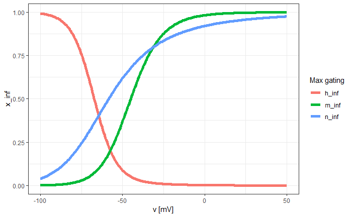

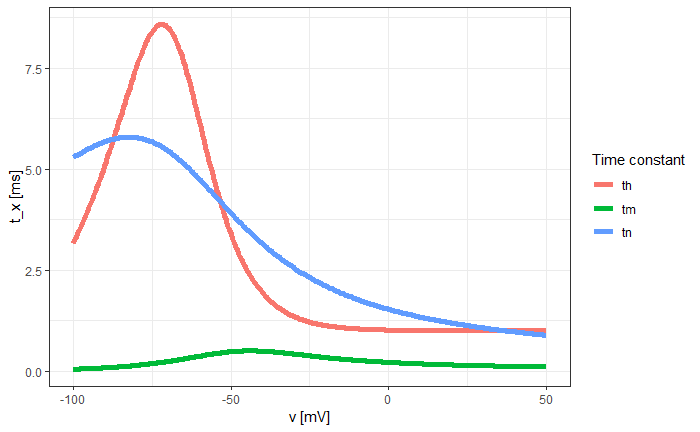